# IODS course project

Elmeri Santala

# Exercise2: Analysis

Code for data wrangling: https://github.com/elmeris/IODS-project/blob/master/data/create_learning2014.R

**reading data**

```r
learning2014 <- read.csv("~/IODS-project/data/learning2014.csv")
str(learning2014)
```

```
## 'data.frame':    166 obs. of  7 variables:
##  $ gender  : Factor w/ 2 levels "F","M": 1 2 1 2 2 1 2 1 2 1 ...
##  $ age     : int  53 55 49 53 49 38 50 37 37 42 ...
##  $ attitude: num  3.7 3.1 2.5 3.5 3.7 3.8 3.5 2.9 3.8 2.1 ...
##  $ deep    : num  3.58 2.92 3.5 3.5 3.67 ...
##  $ stra    : num  3.38 2.75 3.62 3.12 3.62 ...
##  $ surf    : num  2.58 3.17 2.25 2.25 2.83 ...
##  $ points  : int  25 12 24 10 22 21 21 31 24 26 ...
```

```r
head(learning2014)
```

```
##   gender age attitude     deep  stra     surf points
## 1      F  53      3.7 3.583333 3.375 2.583333     25
## 2      M  55      3.1 2.916667 2.750 3.166667     12
## 3      F  49      2.5 3.500000 3.625 2.250000     24
## 4      M  53      3.5 3.500000 3.125 2.250000     10
## 5      M  49      3.7 3.666667 3.625 2.833333     22
## 6      F  38      3.8 4.750000 3.625 2.416667     21
```

```r
dim(learning2014)
```

```
## [1] 166   7
```

There is seven variables and 166 observations.

**Graphical overview**

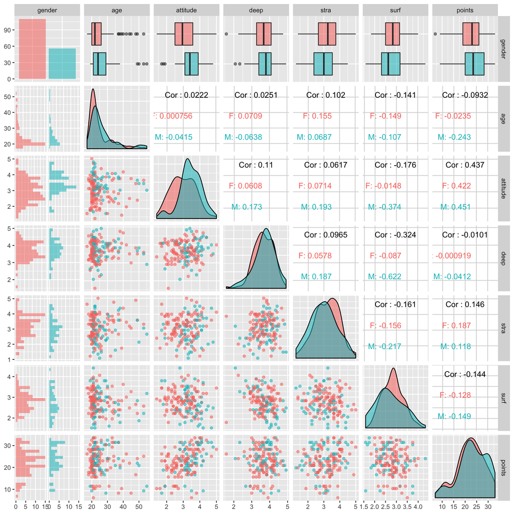

```r
# access the GGally and ggplot2 libraries
library(GGally)
library(ggplot2)

# create a more advanced plot matrix with ggpairs()
p <- ggpairs(learning2014, mapping = aes(col = gender, alpha = 0.3), lower = list(combo = wrap("facethist", bins = 20)))

# draw the plot
p
```

Highest correlation is between points and attitude. All distributions looks even but age is converted to the right.

**Regression model**

The explanatory variables are “surface”, “attitude” and “strategy”

*Scatter plot*

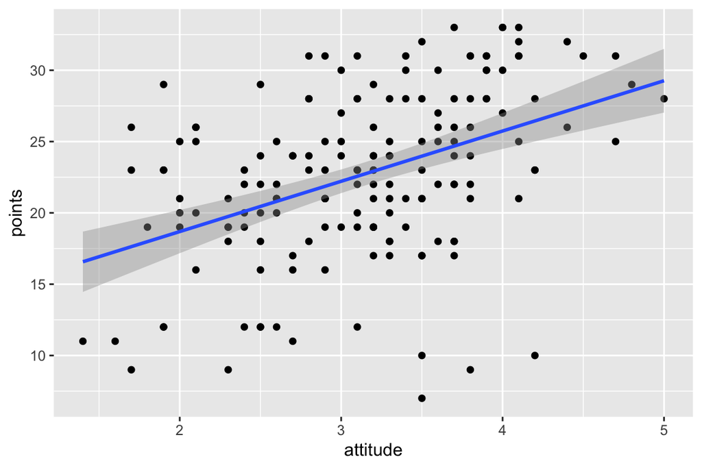

```r
qplot(attitude, points, data = learning2014) + geom_smooth(method = "lm")
```

*a linear model*

```r
model <- lm(points ~1, data = learning2014)
```

*Summary of the model*

```r
summary(model)
```

```
##
## Call:
## lm(formula = points ~ 1, data = learning2014)
##
## Residuals:
##      Min       1Q   Median       3Q      Max
## -15.7169  -3.7169   0.2831   5.0331  10.2831
##
## Coefficients:
##             Estimate Std. Error t value Pr(>|t|)
## (Intercept)  22.7169     0.4575   49.65   <2e-16 ***
## ---
## Signif. codes:  0 '***' 0.001 '**' 0.01 '*' 0.05 '.' 0.1 ' ' 1
##
## Residual standard error: 5.895 on 165 degrees of freedom
```

*Regression model with multiple explanatory variables*

```r
my_model2 <- lm(points ~ attitude + stra + surf, data = learning2014)
```

*Summary of the model2*

```r
summary(my_model2)
```

```
##
## Call:
## lm(formula = points ~ attitude + stra + surf, data = learning2014)
##
## Residuals:
##      Min       1Q   Median       3Q      Max
## -17.1550  -3.4346   0.5156   3.6401  10.8952
##
## Coefficients:
##             Estimate Std. Error t value Pr(>|t|)
## (Intercept)  11.0171     3.6837   2.991  0.00322 **
## attitude      3.3952     0.5741   5.913 1.93e-08 ***
## stra          0.8531     0.5416   1.575  0.11716
## surf         -0.5861     0.8014  -0.731  0.46563
## ---
## Signif. codes:  0 '***' 0.001 '**' 0.01 '*' 0.05 '.' 0.1 ' ' 1
##
## Residual standard error: 5.296 on 162 degrees of freedom
## Multiple R-squared:  0.2074, Adjusted R-squared:  0.1927
## F-statistic: 14.13 on 3 and 162 DF,  p-value: 3.156e-08
```

Lets move surf out because the p-vaöue is the highest.

*New model*

```r
my_model3 <- lm(points ~ attitude + stra, data = learning2014)
```

*summary*

```r
summary(my_model3)
```

```
##
## Call:
## lm(formula = points ~ attitude + stra, data = learning2014)
##
## Residuals:
##      Min       1Q   Median       3Q      Max
## -17.6436  -3.3113   0.5575   3.7928  10.9295
##
## Coefficients:
##             Estimate Std. Error t value Pr(>|t|)
## (Intercept)   8.9729     2.3959   3.745  0.00025 ***
## attitude      3.4658     0.5652   6.132 6.31e-09 ***
## stra          0.9137     0.5345   1.709  0.08927 .
## ---
## Signif. codes:  0 '***' 0.001 '**' 0.01 '*' 0.05 '.' 0.1 ' ' 1
##
## Residual standard error: 5.289 on 163 degrees of freedom
## Multiple R-squared:  0.2048, Adjusted R-squared:  0.1951
## F-statistic: 20.99 on 2 and 163 DF,  p-value: 7.734e-09
```

**Diagnostic plot**

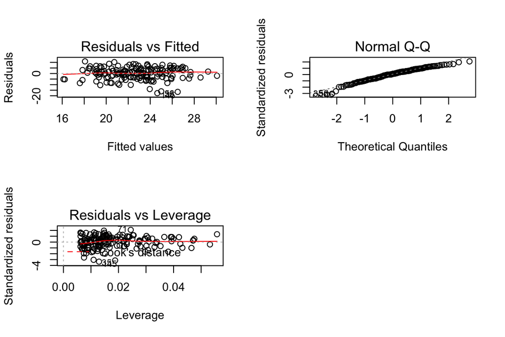

```r
par(mfrow = c(2,2))
plot(my_model3, which = c(1,2,5))
```

QQ plot: model is normally distributed

# Exercise3: Analysis

**Data wrangling** I read the data from URL web page, joined the two data sets using the variables “school”, “sex”, “age”, “address”, “famsize”, “Pstatus”, “Medu”, “Fedu”, “Mjob”, “Fjob”, “reason”, “nursery”,“internet” as (student) identifiers. I Kept only the students present in both data sets. Then, I took the average of the answers related to weekday and weekend alcohol consumption to create a new column ‘alc_use’ to the joined data. Then I used ‘alc_use’ to create a new logical column ‘high_use’ which is TRUE for students for which ‘alc_use’ is greater than 2 (the range is: from 1 - very low to 5 - very high).

Code for data wrangling: https://github.com/elmeris/IODS-project/blob/master/data/create_alc.R

**Reading data**

```r
alc <- read.csv("~/IODS-project/data/alc.csv")
head(alc)
```

```
##   school sex age address famsize Pstatus Medu Fedu     Mjob     Fjob
## 1     GP   F  18       U     GT3       A    4    4  at_home  teacher
## 2     GP   F  17       U     GT3       T    1    1  at_home    other
## 3     GP   F  15       U     LE3       T    1    1  at_home    other
## 4     GP   F  15       U     GT3       T    4    2   health services
## 5     GP   F  16       U     GT3       T    3    3    other    other
## 6     GP   M  16       U     LE3       T    4    3 services    other
##       reason nursery internet guardian traveltime studytime failures
## 1     course     yes       no   mother          2         2        0
## 2     course      no      yes   father          1         2        0
## 3      other     yes      yes   mother          1         2        2
## 4       home     yes      yes   mother          1         3        0
## 5       home     yes       no   father          1         2        0
## 6 reputation     yes      yes   mother          1         2        0
##   schoolsup famsup paid activities higher romantic famrel freetime goout
## 1       yes     no   no         no    yes       no      4        3     4
## 2        no    yes   no         no    yes       no      5        3     3
## 3       yes     no  yes         no    yes       no      4        3     2
## 4        no    yes  yes        yes    yes      yes      3        2     2
## 5        no    yes  yes         no    yes       no      4        3     2
## 6        no    yes  yes        yes    yes       no      5        4     2
##   Dalc Walc health absences G1 G2 G3 alc_use high_use
## 1    1    1      3        5  2  8  8     1.0    FALSE
## 2    1    1      3        3  7  8  8     1.0    FALSE
## 3    2    3      3        8 10 10 11     2.5     TRUE
## 4    1    1      5        1 14 14 14     1.0    FALSE
## 5    1    2      5        2  8 12 12     1.5    FALSE
## 6    1    2      5        8 14 14 14     1.5    FALSE
```

```r
colnames(alc)
```

```
##  [1] "school"     "sex"        "age"        "address"    "famsize"
##  [6] "Pstatus"    "Medu"       "Fedu"       "Mjob"       "Fjob"
## [11] "reason"     "nursery"    "internet"   "guardian"   "traveltime"
## [16] "studytime"  "failures"   "schoolsup"  "famsup"     "paid"
## [21] "activities" "higher"     "romantic"   "famrel"     "freetime"
## [26] "goout"      "Dalc"       "Walc"       "health"     "absences"
## [31] "G1"         "G2"         "G3"         "alc_use"    "high_use"
```

**My analysis from data**

I am interested in the relationships between high/low alcohol consumption and these four variables: student’s sex (male or female), number of school absences (numeric: from 0 to 93), final grade (numeric: from 0 to 20, output target), age - student’s age (numeric: from 15 to 22).

My hypotesis are: 1) Men consume more alcohol 2) Students with lower grades consume more alcohol 3) Students with more absences consume more alcohol 4) Older students consume more alcohol

Lets find out!

```r
library(tidyr); library(dplyr); library(ggplot2)
glimpse(alc)
```

```
## Observations: 382
## Variables: 35
## $ school     <fct> GP, GP, GP, GP, GP, GP, GP, GP, GP, GP, GP, GP, GP, G…
## $ sex        <fct> F, F, F, F, F, M, M, F, M, M, F, F, M, M, M, F, F, F,…
## $ age        <int> 18, 17, 15, 15, 16, 16, 16, 17, 15, 15, 15, 15, 15, 1…
## $ address    <fct> U, U, U, U, U, U, U, U, U, U, U, U, U, U, U, U, U, U,…
## $ famsize    <fct> GT3, GT3, LE3, GT3, GT3, LE3, LE3, GT3, LE3, GT3, GT3…
## $ Pstatus    <fct> A, T, T, T, T, T, T, A, A, T, T, T, T, T, A, T, T, T,…
## $ Medu       <int> 4, 1, 1, 4, 3, 4, 2, 4, 3, 3, 4, 2, 4, 4, 2, 4, 4, 3,…
## $ Fedu       <int> 4, 1, 1, 2, 3, 3, 2, 4, 2, 4, 4, 1, 4, 3, 2, 4, 4, 3,…
## $ Mjob       <fct> at_home, at_home, at_home, health, other, services, o…
## $ Fjob       <fct> teacher, other, other, services, other, other, other,…
## $ reason     <fct> course, course, other, home, home, reputation, home, …
## $ nursery    <fct> yes, no, yes, yes, yes, yes, yes, yes, yes, yes, yes,…
## $ internet   <fct> no, yes, yes, yes, no, yes, yes, no, yes, yes, yes, y…
```

[output cut: 22 more lines]

```r
gather(alc) %>% glimpse
```

```
## Observations: 13,370
## Variables: 2
## $ key   <chr> "school", "school", "school", "school", "school", "school"…
## $ value <chr> "GP", "GP", "GP", "GP", "GP", "GP", "GP", "GP", "GP", "GP"…
```

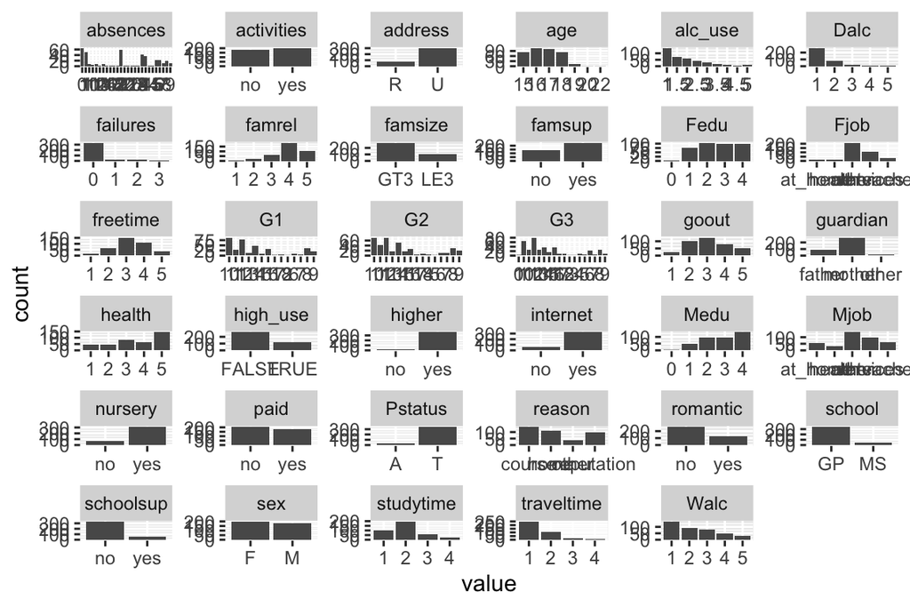

```r
gather(alc) %>% ggplot(aes(value)) + facet_wrap("key", scales = "free") + geom_bar()
```

```r
library(dplyr); library(ggplot2)
```

```r
alc %>% group_by(sex, high_use) %>% summarise(count = n(), mean_grade = mean(G3))
```

```
## # A tibble: 4 x 4
## # Groups:   sex [2]
##   sex   high_use count mean_grade
##   <fct> <lgl>    <int>      <dbl>
## 1 F     FALSE      156       11.4
## 2 F     TRUE        42       11.7
## 3 M     FALSE      112       12.2
## 4 M     TRUE        72       10.3
```

As we can see in the table above that it seems that my first hypothesis was maybe right because men consume more alcohol than women. Yet I dont know is this difference statistically significant or not.

```r
g1 <- ggplot(alc, aes(x = high_use, y = G3, col = sex))
```

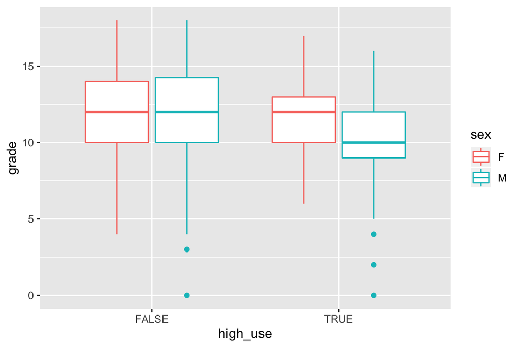

```r
g1 + geom_boxplot() + ylab("grade")
```

As the boxplot above shows the students with lower final grade consume more alcohol. This means my second hypothesis was maybe right. Yet I dont know is this difference statistically significant or not.

```r
g2 <- ggplot(alc, aes(x = high_use, y = absences, col = sex))
```

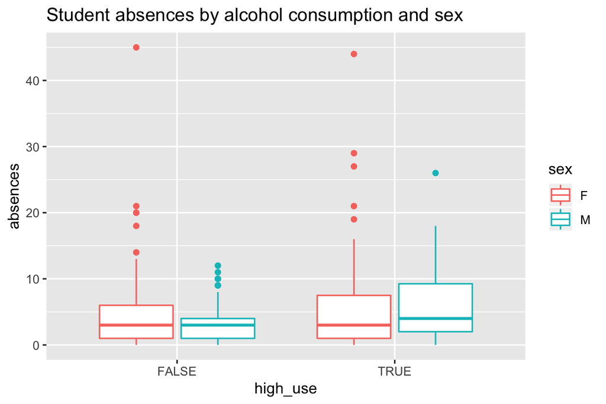

```r
g2 + geom_boxplot() + ggtitle("Student absences by alcohol consumption and sex")
```

As the boxplot above shows the students with more absences consume more alcohol. This means my third hypothesis was maybe right. Yet I dont know is this difference statistically significant or not.

```r
g3 <- ggplot(alc, aes(x = high_use, y = age, col = sex))
```

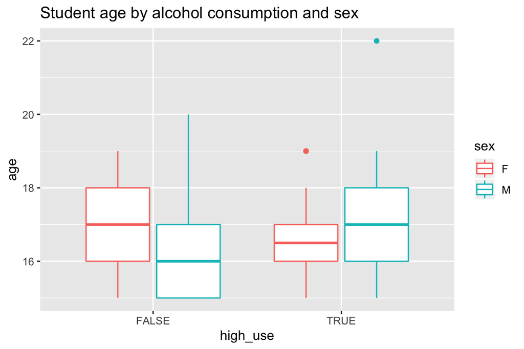

```r
g3 + geom_boxplot() + ggtitle("Student age by alcohol consumption and sex")
```

```r
m <- glm(high_use ~ age + G3 + absences + sex, data = alc, family = "binomial")
```

```r
summary(m)
```

```
##
## Call:
## glm(formula = high_use ~ age + G3 + absences + sex, family = "binomial",
##     data = alc)
##
## Deviance Residuals:
##     Min       1Q   Median       3Q      Max
## -2.2729  -0.8326  -0.6292   1.0442   2.1190
##
## Coefficients:
##             Estimate Std. Error z value Pr(>|z|)
## (Intercept) -3.38339    1.84796  -1.831 0.067120 .
## age          0.13985    0.10328   1.354 0.175690
## G3          -0.06631    0.03624  -1.830 0.067277 .
## absences     0.08964    0.02309   3.882 0.000104 ***
## sexM         0.98580    0.24184   4.076 4.58e-05 ***
## ---
## Signif. codes:  0 '***' 0.001 '**' 0.01 '*' 0.05 '.' 0.1 ' ' 1
##
## (Dispersion parameter for binomial family taken to be 1)
##
##     Null deviance: 465.68  on 381  degrees of freedom
## Residual deviance: 423.66  on 377  degrees of freedom
## AIC: 433.66
##
## Number of Fisher Scoring iterations: 4
```

```r
coef(m)
```

```
## (Intercept)         age          G3    absences        sexM
## -3.38338833  0.13985344 -0.06630516  0.08963638  0.98580237
```

```r
m <- glm(high_use ~ age + G3 + absences + sex, data = alc, family = "binomial")
```

```r
OR <- coef(m) %>% exp
```

```r
CI <- confint(m) %>% exp
cbind(OR, CI)
```

```
##                     OR        2.5 %   97.5 %
## (Intercept) 0.03393229 0.0008683319 1.237502
## age         1.15010522 0.9401979286 1.410759
## G3          0.93584524 0.8710385897 1.004426
## absences    1.09377649 1.0474354900 1.146836
## sexM        2.67996134 1.6781593816 4.338864
```

The fitted logistic regression model demonstrate that two of my chosen variables: absences and sex are statistically significant in relation to alcohol consumption. These variables have a p-value of <0.001.

The two other variables: age and final grade did not show statistical significance in relation to alcohol consumption.

Sex: Odds ratio shows us that the male students have higher alcohol consumption 2.7 times more likely than female students. (95% Cl 1.68-4.34)

**Prediction of the probability of high_use**

```r
probabilities <- predict(m, type = "response")
```

```r
alc <- mutate(alc, probability = probabilities)
```

```r
alc <- mutate(alc, prediction = probability > 0.5)
```

```r
table(high_use = alc$high_use, prediction = alc$prediction)
```

```
##         prediction
## high_use FALSE TRUE
##    FALSE   255   13
##    TRUE     84   30
```

```r
table(high_use = alc$high_use, prediction = alc$prediction) %>% prop.table %>% addmargins
```

```
##         prediction
## high_use      FALSE       TRUE        Sum
##    FALSE 0.66753927 0.03403141 0.70157068
##    TRUE  0.21989529 0.07853403 0.29842932
##    Sum   0.88743455 0.11256545 1.00000000
```

These tables shows us that in 339 false (low alcohol use) predictions 255 were really false, thats about 75%, and in 43 true (high alcohol use) predictions 30 were really true, thats about 70%.

**Visualizing the prediction of the probability of high_use**

```r
library(dplyr); library(ggplot2)
```

```r
g <- ggplot(alc, aes(x = probability, y = high_use, col = prediction))
```

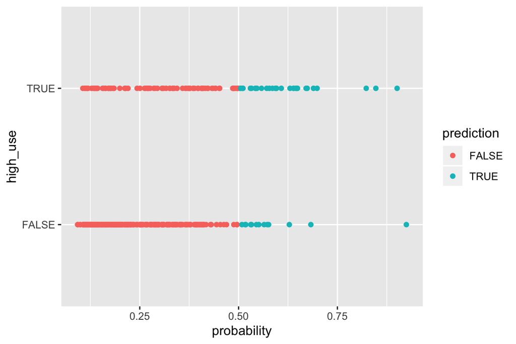

```r
g + geom_point()
```

This plot shows us that the prediction of correct classification is quite good, but there is some misclassifications with this model.

# Exercise 4 / Clustering and classification: Analysis

## Task 1

### 1.1 strarting

I created a new RMarkdown file and saved it as an empty file named ‘chapter4.Rmd’. Then I included the file as a child file in my ‘index.Rmd’ file.

This week I used the Boston Housing Dataset for the exercise

## Task 2

### 2.1 Loading and exploring the structure and the dimensions of the data

```
## 'data.frame':    506 obs. of  14 variables:
##  $ crim   : num  0.00632 0.02731 0.02729 0.03237 0.06905 ...
##  $ zn     : num  18 0 0 0 0 0 12.5 12.5 12.5 12.5 ...
##  $ indus  : num  2.31 7.07 7.07 2.18 2.18 2.18 7.87 7.87 7.87 7.87 ...
##  $ chas   : int  0 0 0 0 0 0 0 0 0 0 ...
##  $ nox    : num  0.538 0.469 0.469 0.458 0.458 0.458 0.524 0.524 0.524 0.524 ...
##  $ rm     : num  6.58 6.42 7.18 7 7.15 ...
##  $ age    : num  65.2 78.9 61.1 45.8 54.2 58.7 66.6 96.1 100 85.9 ...
##  $ dis    : num  4.09 4.97 4.97 6.06 6.06 ...
##  $ rad    : int  1 2 2 3 3 3 5 5 5 5 ...
##  $ tax    : num  296 242 242 222 222 222 311 311 311 311 ...
##  $ ptratio: num  15.3 17.8 17.8 18.7 18.7 18.7 15.2 15.2 15.2 15.2 ...
##  $ black  : num  397 397 393 395 397 ...
##  $ lstat  : num  4.98 9.14 4.03 2.94 5.33 ...
##  $ medv   : num  24 21.6 34.7 33.4 36.2 28.7 22.9 27.1 16.5 18.9 ...
```

```
## [1] 506  14
```

```
##  [1] "crim"    "zn"      "indus"   "chas"    "nox"     "rm"      "age"
##  [8] "dis"     "rad"     "tax"     "ptratio" "black"   "lstat"   "medv"
```

**Description** The Boston Housing Dataset is a derived from information collected by the U.S. Census Service concerning housing in the area of Boston MA. The Boston data frame has 506 rows and 14 columns. The following describes the dataset columns:

| VARIABLE | DESCRIPTION |
| --- | --- |
| `"CRIM"` | per capita crime rate by town |
| `"ZN"` | proportion of residential land zoned for lots over 25,000 sq.ft. |
| `"INDUS"` | proportion of non-retail business acres per town. |
| `"CHAS"` | Charles River dummy variable (1 if tract bounds river; 0 otherwise) |
| `"NOX"` | nitric oxides concentration (parts per 10 million) |
| `"RM"` | average number of rooms per dwelling |
| `"AGE"` | proportion of owner-occupied units built prior to 1940 |
| `"DIS"` | weighted distances to five Boston employment centres |
| `"RAD"` | index of accessibility to radial highways |
| `"TAX"` | full-value property-tax rate per $10,000 |
| `"PTRATIO"` | upil-teacher ratio by town |
| `"B - 1000(Bk - 0.63)^2"` | where Bk is the proportion of blacks by town |
| `"LSTAT"` | % lower status of the population |
| `"MEDV"` | Median value of owner-occupied homes in $1000’s |

## Task 3

### 3.1 Graphical overview of the data and summaries of the variables in the data

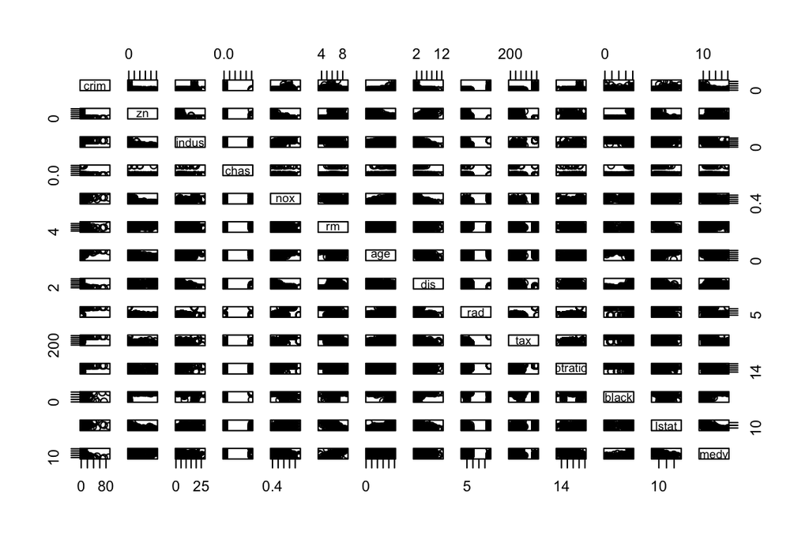

```
##       crim                zn             indus            chas
##  Min.   : 0.00632   Min.   :  0.00   Min.   : 0.46   Min.   :0.00000
##  1st Qu.: 0.08204   1st Qu.:  0.00   1st Qu.: 5.19   1st Qu.:0.00000
##  Median : 0.25651   Median :  0.00   Median : 9.69   Median :0.00000
##  Mean   : 3.61352   Mean   : 11.36   Mean   :11.14   Mean   :0.06917
##  3rd Qu.: 3.67708   3rd Qu.: 12.50   3rd Qu.:18.10   3rd Qu.:0.00000
##  Max.   :88.97620   Max.   :100.00   Max.   :27.74   Max.   :1.00000
##       nox               rm             age              dis
##  Min.   :0.3850   Min.   :3.561   Min.   :  2.90   Min.   : 1.130
##  1st Qu.:0.4490   1st Qu.:5.886   1st Qu.: 45.02   1st Qu.: 2.100
##  Median :0.5380   Median :6.208   Median : 77.50   Median : 3.207
##  Mean   :0.5547   Mean   :6.285   Mean   : 68.57   Mean   : 3.795
##  3rd Qu.:0.6240   3rd Qu.:6.623   3rd Qu.: 94.08   3rd Qu.: 5.188
##  Max.   :0.8710   Max.   :8.780   Max.   :100.00   Max.   :12.127
##       rad              tax           ptratio          black
##  Min.   : 1.000   Min.   :187.0   Min.   :12.60   Min.   :  0.32
##  1st Qu.: 4.000   1st Qu.:279.0   1st Qu.:17.40   1st Qu.:375.38
##  Median : 5.000   Median :330.0   Median :19.05   Median :391.44
##  Mean   : 9.549   Mean   :408.2   Mean   :18.46   Mean   :356.67
##  3rd Qu.:24.000   3rd Qu.:666.0   3rd Qu.:20.20   3rd Qu.:396.23
##  Max.   :24.000   Max.   :711.0   Max.   :22.00   Max.   :396.90
##      lstat            medv
##  Min.   : 1.73   Min.   : 5.00
##  1st Qu.: 6.95   1st Qu.:17.02
##  Median :11.36   Median :21.20
##  Mean   :12.65   Mean   :22.53
##  3rd Qu.:16.95   3rd Qu.:25.00
##  Max.   :37.97   Max.   :50.00
```

```
##          crim    zn indus  chas   nox    rm   age   dis   rad   tax
## crim     1.00 -0.20  0.41 -0.06  0.42 -0.22  0.35 -0.38  0.63  0.58
## zn      -0.20  1.00 -0.53 -0.04 -0.52  0.31 -0.57  0.66 -0.31 -0.31
## indus    0.41 -0.53  1.00  0.06  0.76 -0.39  0.64 -0.71  0.60  0.72
## chas    -0.06 -0.04  0.06  1.00  0.09  0.09  0.09 -0.10 -0.01 -0.04
## nox      0.42 -0.52  0.76  0.09  1.00 -0.30  0.73 -0.77  0.61  0.67
## rm      -0.22  0.31 -0.39  0.09 -0.30  1.00 -0.24  0.21 -0.21 -0.29
## age      0.35 -0.57  0.64  0.09  0.73 -0.24  1.00 -0.75  0.46  0.51
## dis     -0.38  0.66 -0.71 -0.10 -0.77  0.21 -0.75  1.00 -0.49 -0.53
## rad      0.63 -0.31  0.60 -0.01  0.61 -0.21  0.46 -0.49  1.00  0.91
## tax      0.58 -0.31  0.72 -0.04  0.67 -0.29  0.51 -0.53  0.91  1.00
## ptratio  0.29 -0.39  0.38 -0.12  0.19 -0.36  0.26 -0.23  0.46  0.46
## black   -0.39  0.18 -0.36  0.05 -0.38  0.13 -0.27  0.29 -0.44 -0.44
## lstat    0.46 -0.41  0.60 -0.05  0.59 -0.61  0.60 -0.50  0.49  0.54
## medv    -0.39  0.36 -0.48  0.18 -0.43  0.70 -0.38  0.25 -0.38 -0.47
##         ptratio black lstat  medv
## crim       0.29 -0.39  0.46 -0.39
## zn        -0.39  0.18 -0.41  0.36
## indus      0.38 -0.36  0.60 -0.48
## chas      -0.12  0.05 -0.05  0.18
## nox        0.19 -0.38  0.59 -0.43
## rm        -0.36  0.13 -0.61  0.70
## age        0.26 -0.27  0.60 -0.38
## dis       -0.23  0.29 -0.50  0.25
## rad        0.46 -0.44  0.49 -0.38
## tax        0.46 -0.44  0.54 -0.47
## ptratio    1.00 -0.18  0.37 -0.51
## black     -0.18  1.00 -0.37  0.33
## lstat      0.37 -0.37  1.00 -0.74
## medv      -0.51  0.33 -0.74  1.00
```

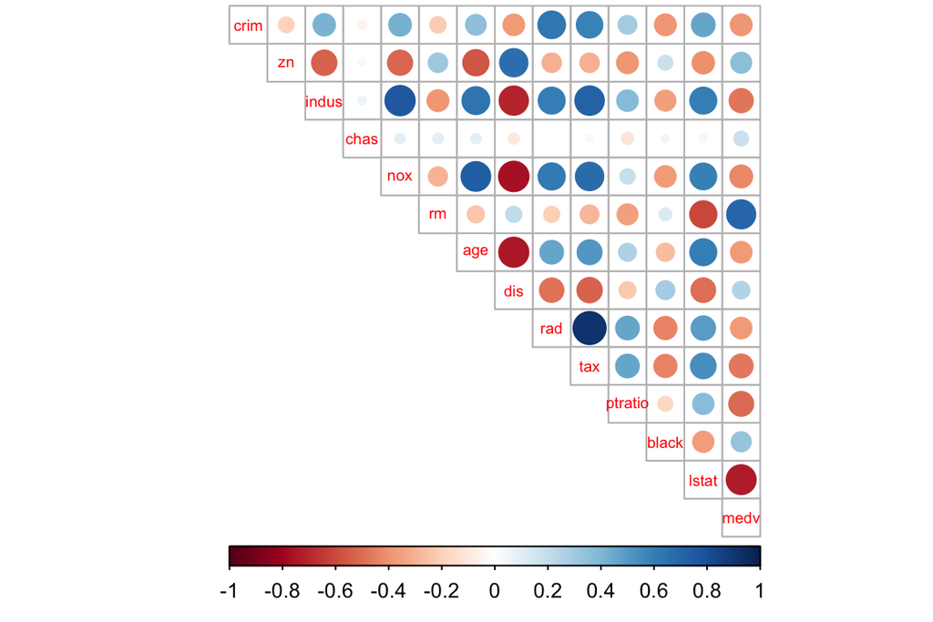

**Description** *The graphical overview:* First graph gives us some info about which combination of varibles produces some kind of clusters. For example `rad age`seems to produse some clusters.

The graphical display of a correlation matrix shows us the correlation between pairs of variables. For exemple the correlation between variables tax and rad is high.

*Summaries of thevariables* The summary shows the minimum and maximum values, quarters, and mean for each variable. For example for the variable the mean value is 0.5547.

## Task 4

### 4.1 Standardizing the dataset and printing out summaries of the scaled data.

```
##       crim                 zn               indus
##  Min.   :-0.419367   Min.   :-0.48724   Min.   :-1.5563
##  1st Qu.:-0.410563   1st Qu.:-0.48724   1st Qu.:-0.8668
##  Median :-0.390280   Median :-0.48724   Median :-0.2109
##  Mean   : 0.000000   Mean   : 0.00000   Mean   : 0.0000
##  3rd Qu.: 0.007389   3rd Qu.: 0.04872   3rd Qu.: 1.0150
##  Max.   : 9.924110   Max.   : 3.80047   Max.   : 2.4202
##       chas              nox                rm               age
##  Min.   :-0.2723   Min.   :-1.4644   Min.   :-3.8764   Min.   :-2.3331
##  1st Qu.:-0.2723   1st Qu.:-0.9121   1st Qu.:-0.5681   1st Qu.:-0.8366
##  Median :-0.2723   Median :-0.1441   Median :-0.1084   Median : 0.3171
##  Mean   : 0.0000   Mean   : 0.0000   Mean   : 0.0000   Mean   : 0.0000
##  3rd Qu.:-0.2723   3rd Qu.: 0.5981   3rd Qu.: 0.4823   3rd Qu.: 0.9059
##  Max.   : 3.6648   Max.   : 2.7296   Max.   : 3.5515   Max.   : 1.1164
##       dis               rad               tax             ptratio
##  Min.   :-1.2658   Min.   :-0.9819   Min.   :-1.3127   Min.   :-2.7047
##  1st Qu.:-0.8049   1st Qu.:-0.6373   1st Qu.:-0.7668   1st Qu.:-0.4876
##  Median :-0.2790   Median :-0.5225   Median :-0.4642   Median : 0.2746
##  Mean   : 0.0000   Mean   : 0.0000   Mean   : 0.0000   Mean   : 0.0000
##  3rd Qu.: 0.6617   3rd Qu.: 1.6596   3rd Qu.: 1.5294   3rd Qu.: 0.8058
##  Max.   : 3.9566   Max.   : 1.6596   Max.   : 1.7964   Max.   : 1.6372
##      black             lstat              medv
##  Min.   :-3.9033   Min.   :-1.5296   Min.   :-1.9063
##  1st Qu.: 0.2049   1st Qu.:-0.7986   1st Qu.:-0.5989
##  Median : 0.3808   Median :-0.1811   Median :-0.1449
##  Mean   : 0.0000   Mean   : 0.0000   Mean   : 0.0000
##  3rd Qu.: 0.4332   3rd Qu.: 0.6024   3rd Qu.: 0.2683
##  Max.   : 0.4406   Max.   : 3.5453   Max.   : 2.9865
```

```
## [1] "matrix"
```

**Description** After standardization, the mean of all variables is zero. Also the minimum, maximum, and quarters values have changed.

### 4.2 Creating a categorical variable of the crime rate and dropping the old crime rate variable from the dataset.

```
##           0%          25%          50%          75%         100%
## -0.419366929 -0.410563278 -0.390280295  0.007389247  9.924109610
```

```
## crime
##      low  med_low med_high     high
##      127      126      126      127
```

**Description** I used the quantiles as the break points in the new crime categorical variable. This new variable has the following categories: *low, med_low, med_high, high*. The old crime rate variable is now dropped from the dataset.

### 4.3 Dividing the dataset to train and test sets, so that 80% of the data belongs to the train set

## Task 5

### 5.1 Fitting the linear discriminant analysis on the train set by using the categorical crime rate as the target variable and all the other variables in the dataset as predictor variables.

```
## Call:
## lda(crime ~ ., data = train)
##
## Prior probabilities of groups:
##       low   med_low  med_high      high
## 0.2400990 0.2475248 0.2648515 0.2475248
##
## Group means:
##                   zn      indus         chas        nox          rm
## low       1.03644527 -0.9009748 -0.150563081 -0.8901780  0.42517714
## med_low  -0.07390459 -0.3098643  0.003267949 -0.5771263 -0.08574284
## med_high -0.40629457  0.2279721  0.242805543  0.3829069  0.17166952
## high     -0.48724019  1.0171519 -0.154216061  1.0682380 -0.48917734
##                 age        dis        rad        tax    ptratio
## low      -0.9154077  0.8950364 -0.6870585 -0.7147010 -0.4780328
## med_low  -0.3580572  0.3379427 -0.5431568 -0.4681886 -0.1106419
## med_high  0.4275950 -0.3945159 -0.3883177 -0.2752313 -0.2570356
## high      0.7962347 -0.8473273  1.6377820  1.5138081  0.7803736
##                black       lstat        medv
## low       0.38196940 -0.77236941  0.52640706
## med_low   0.31240277 -0.17274228  0.02176703
## med_high  0.08585395 -0.02507254  0.20708441
## high     -0.84312006  0.85356172 -0.72759928
##
## Coefficients of linear discriminants:
##                  LD1           LD2         LD3
## zn       0.081092641  0.8172237294 -1.01699186
## indus    0.004360172 -0.2986686406  0.12957013
## chas    -0.114672999 -0.0883457566  0.07859910
## nox      0.446479652 -0.6516049702 -1.37426787
## rm      -0.087522506 -0.1682157401 -0.12711886
## age      0.289996428 -0.3257270848 -0.19856491
## dis     -0.045534961 -0.3196183299  0.11158892
## rad      2.979466295  0.9057150547 -0.01310176
## tax     -0.015848463  0.0005681882  0.58570266
## ptratio  0.112200263 -0.0277781453 -0.33572165
## black   -0.142664300  0.0087844578  0.11041765
## lstat    0.189625185 -0.2171372290  0.44803693
## medv     0.172550796 -0.3994618181 -0.20361333
##
## Proportion of trace:
##    LD1    LD2    LD3
## 0.9381 0.0478 0.0141
```

### 5.2 Drawing the LDA (bi)plot.

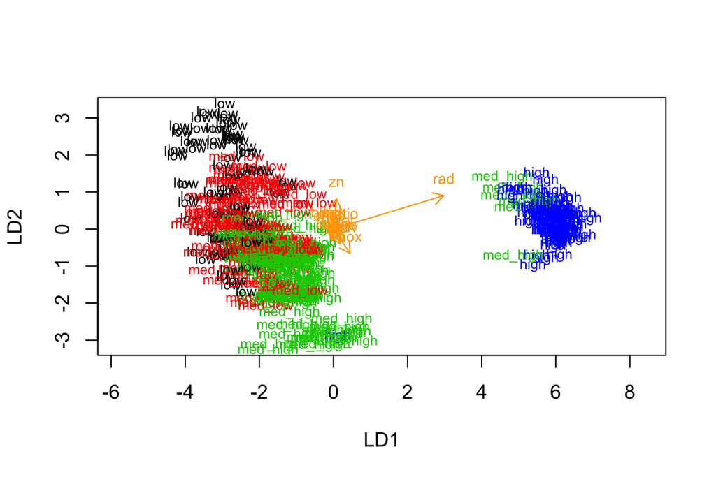

In the last section we’ll see proportion of trace which is the proportion of crime categories that is explained by successive discriminant functions. As we can see the LD1 has highest proportion of trace.

*5.2* From the graph we can see that correlation between `rad zn` and `zn nox` is pretty low. As we know already from the task 3 those correlations are : `rad zn` -0.31 `zn nox` -0.52 Also we can see that variable rad is the feature contributing to LD1 dimension.

## Task 6

### 6.1 Saving the crime categories from the test set and then removing the categorical crime variable from the test dataset.

### 6.2 Predicting the classes with the LDA model on the test data. Then cross tabulating the results with the crime categories from the test set.

```
##           predicted
## correct    low med_low med_high high
##   low       12      16        2    0
##   med_low    1      20        5    0
##   med_high   1       4       14    0
##   high       0       0        0   27
```

## Task 7

### 7.1 Reloading the Boston dataset and standardizing the dataset

```r
library(MASS)
data("Boston")
boston_scaled <- scale(Boston)
summary(boston_scaled)
```

```
##       crim                 zn               indus
##  Min.   :-0.419367   Min.   :-0.48724   Min.   :-1.5563
##  1st Qu.:-0.410563   1st Qu.:-0.48724   1st Qu.:-0.8668
##  Median :-0.390280   Median :-0.48724   Median :-0.2109
##  Mean   : 0.000000   Mean   : 0.00000   Mean   : 0.0000
##  3rd Qu.: 0.007389   3rd Qu.: 0.04872   3rd Qu.: 1.0150
##  Max.   : 9.924110   Max.   : 3.80047   Max.   : 2.4202
##       chas              nox                rm               age
##  Min.   :-0.2723   Min.   :-1.4644   Min.   :-3.8764   Min.   :-2.3331
##  1st Qu.:-0.2723   1st Qu.:-0.9121   1st Qu.:-0.5681   1st Qu.:-0.8366
##  Median :-0.2723   Median :-0.1441   Median :-0.1084   Median : 0.3171
##  Mean   : 0.0000   Mean   : 0.0000   Mean   : 0.0000   Mean   : 0.0000
##  3rd Qu.:-0.2723   3rd Qu.: 0.5981   3rd Qu.: 0.4823   3rd Qu.: 0.9059
##  Max.   : 3.6648   Max.   : 2.7296   Max.   : 3.5515   Max.   : 1.1164
##       dis               rad               tax             ptratio
##  Min.   :-1.2658   Min.   :-0.9819   Min.   :-1.3127   Min.   :-2.7047
##  1st Qu.:-0.8049   1st Qu.:-0.6373   1st Qu.:-0.7668   1st Qu.:-0.4876
##  Median :-0.2790   Median :-0.5225   Median :-0.4642   Median : 0.2746
##  Mean   : 0.0000   Mean   : 0.0000   Mean   : 0.0000   Mean   : 0.0000
##  3rd Qu.: 0.6617   3rd Qu.: 1.6596   3rd Qu.: 1.5294   3rd Qu.: 0.8058
##  Max.   : 3.9566   Max.   : 1.6596   Max.   : 1.7964   Max.   : 1.6372
##      black             lstat              medv
##  Min.   :-3.9033   Min.   :-1.5296   Min.   :-1.9063
##  1st Qu.: 0.2049   1st Qu.:-0.7986   1st Qu.:-0.5989
##  Median : 0.3808   Median :-0.1811   Median :-0.1449
##  Mean   : 0.0000   Mean   : 0.0000   Mean   : 0.0000
##  3rd Qu.: 0.4332   3rd Qu.: 0.6024   3rd Qu.: 0.2683
##  Max.   : 0.4406   Max.   : 3.5453   Max.   : 2.9865
```

```r
class(boston_scaled)
```

```
## [1] "matrix"
```

```r
boston_scaled <- as.data.frame(boston_scaled)
```

### 7.2 Distances between the observations

```
##    Min. 1st Qu.  Median    Mean 3rd Qu.    Max.
##  0.1343  3.4625  4.8241  4.9111  6.1863 14.3970
```

```
##    Min. 1st Qu.  Median    Mean 3rd Qu.    Max.
##  0.2662  8.4832 12.6090 13.5488 17.7568 48.8618
```

**Description** Distance between the observations calculated with two different methods: `Euclidian distances` (Ordinary" straight-line distance between two points in Euclidean space) and `Manhattan distances`(The distance between two points measured along axes at right angles). This case Euclidian distance mean is 4.9111 and median 4.8241 and Manhattan distance mean is 13.5488 and median 12.6090.

### 7.3 Runing k-means algorithm on the dataset and visualizing the cluster.

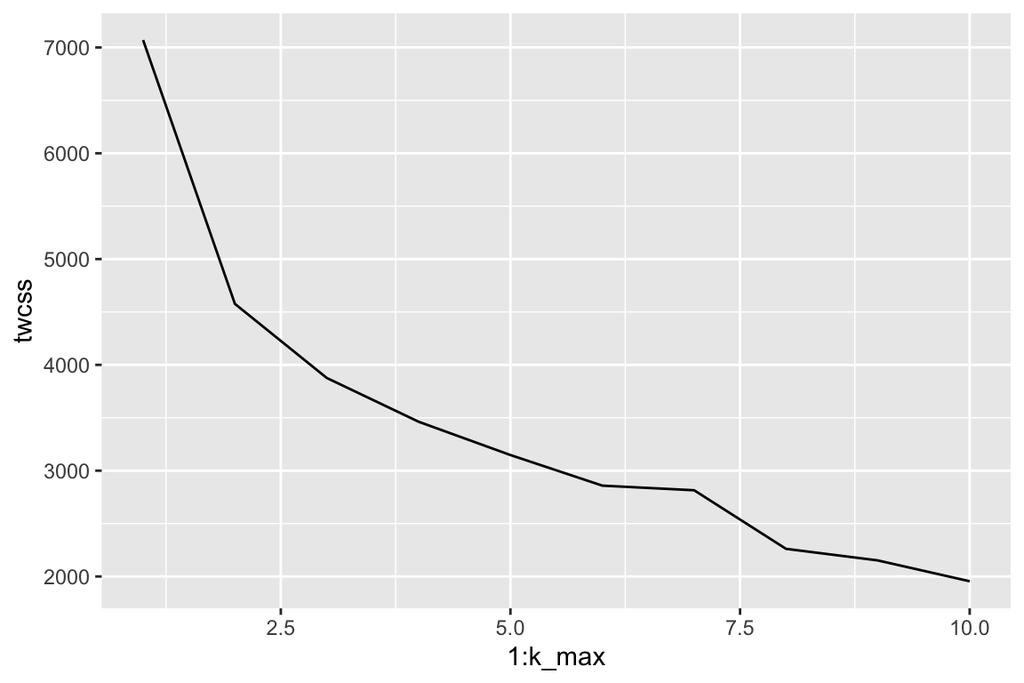

**Description** For investigating what is the optimal number of clusters I will use the elbow method:

1. Compute clustering algorithm (e.g., k-means clustering) for different values of k. For instance, by varying k from 1 to 10 clusters
2. For each k, calculate the total within-cluster sum of square (wss)
3. Plot the curve of wss according to the number of clusters k.
4. The location of a bend (knee) in the plot is generally considered as an indicator of the appropriate number of clusters.

I will say that optimal number of clusters in this case is 2.

### 7.4 Running the algorithm again and visualizing the cluster.

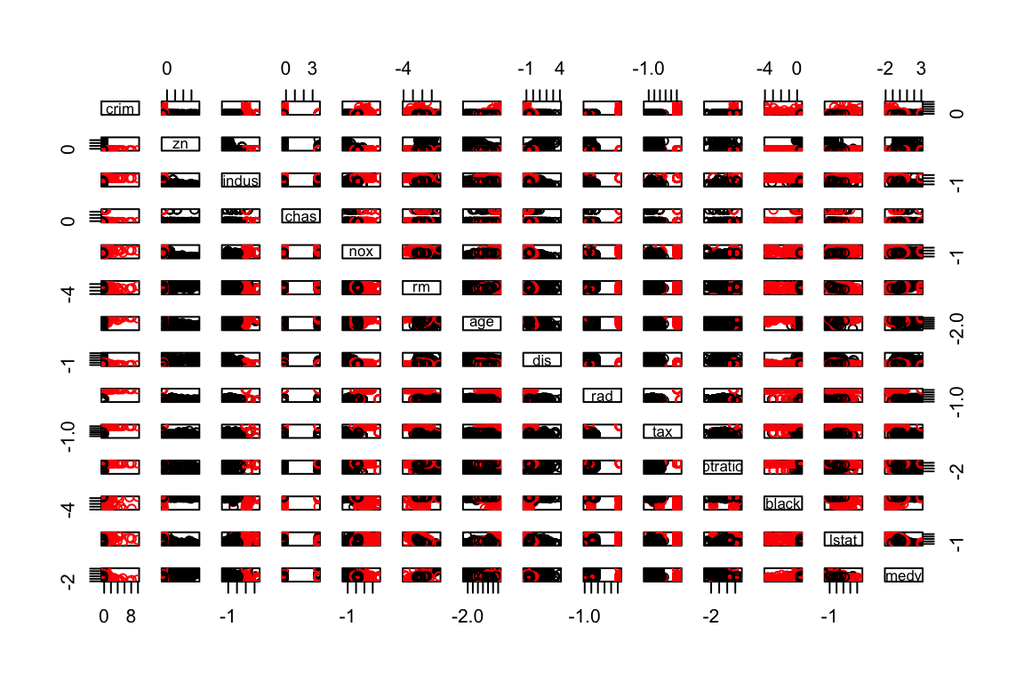

**Description** The graph shows us that which combinations of two variables distinguish the two clusters. For example `tax age`distinguish the two clusters quite well also `tax`with many other variables distinguish the two clusters quite well.